# Task 2: Neighbouring Provinces

Lucia Gomez Llactahuamani

Find and download a shapefile of Peruvian provinces to build an adjacency matrix between them. An adjacency matrix shows whether features are or are not adjacent or sharing edges. Create a script for building the adjacency matrix and explain if the matrix considers provinces sharing edges or if it considers vertices as well.

```r
# Load the spatial libraries
library(maptools)
library(spdep) # Functions to build and adjacency matrix
library(rgdal) # Installing rgdal for reading shapefiles

# Set working directory
setwd("F:/RESEARCH/OPPORTUNITIES/RA/Tareas-RA-Higher-Education/Tareas-RA-Higher-Education/Quantitative_tasks/Task2_neighbouring_provinces/provicia_files")

# Load in data
getinfo.shape("PROVINCIAS.shp")
```

```
TRUE Shapefile type: Polygon, (5), # of Shapes: 196
```

```r
provincias <- rgdal::readOGR(".", "PROVINCIAS")
```

```
TRUE OGR data source with driver: ESRI Shapefile
TRUE Source: "F:\RESEARCH\OPPORTUNITIES\RA\Tareas-RA-Higher-Education\Tareas-RA-Higher-Education\Quantitative_tasks\Task2_neighbouring_provinces\provicia_files", layer: "PROVINCIAS"
TRUE with 196 features
TRUE It has 6 fields
```

I developed the following guided by the blog named [Creating neighborhood matrices for Spatial Polygons in R](https://aledemogr.com/2015/10/09/creating-neighborhood-matrices-for-spatial-polygons/).

In the presence of irregular polygons with varing shape and surface, we can use adjacency based relations to define neighbors. The function “poly2nb” allows to create two types of neighbors-list, and from that a neighbors matrix.

1. First Order Queen (FOQ) adjacency

FOQ adjacency defines a neighbor when at least one point of the boundary of one polygon is shared with at least one point of its neighbor (common border or corner).

```r
# Neighbors-list
provincias_foq <- poly2nb(provincias, row.names = provincias$IDPROV, queen = TRUE)
## If "queen=TRUE", a single shared boundary points meets the adjacency condition.

## Build an adjacency matrix
provincias_foq_mx <- nb2listw(provincias_foq, style = "B") # Matrix where the information in stored in a useful way for procedures from the spdep packages.we use “style=B” to use binary (TRUE/FALSE) distance weights.
provincias_foq_mx_classic <- nb2mat(provincias_foq, style = "B") # Classic matrix. we use “style=B” to use binary (TRUE/FALSE) distance weights.
DT::datatable(provincias_foq_mx_classic)
```

|  | V1 | V2 | V3 | V4 | V5 | V6 | V7 | V8 | V9 | V10 | V11 | V12 | V13 | V14 | V15 | V16 | V17 | V18 | V19 | V20 | V21 | V22 | V23 | V24 | V25 | V26 | V27 | V28 | V29 | … |
| --- | --- | --- | --- | --- | --- | --- | --- | --- | --- | --- | --- | --- | --- | --- | --- | --- | --- | --- | --- | --- | --- | --- | --- | --- | --- | --- | --- | --- | --- | --- |
| 0101 | 0 | 0 | 1 | 0 | 1 | 1 | 0 | 0 | 0 | 0 | 0 | 0 | 0 | 0 | 0 | 0 | 0 | 0 | 0 | 0 | 0 | 0 | 0 | 0 | 0 | 0 | 0 | 0 | 0 | … |
| 0102 | 0 | 0 | 0 | 1 | 0 | 0 | 1 | 0 | 0 | 0 | 0 | 0 | 0 | 0 | 0 | 0 | 0 | 0 | 0 | 0 | 0 | 0 | 0 | 0 | 0 | 0 | 0 | 0 | 0 | … |
| 0103 | 1 | 0 | 0 | 1 | 1 | 0 | 1 | 0 | 0 | 0 | 0 | 0 | 0 | 0 | 0 | 0 | 0 | 0 | 0 | 0 | 0 | 0 | 0 | 0 | 0 | 0 | 0 | 0 | 0 | … |
| 0104 | 0 | 1 | 1 | 0 | 0 | 0 | 1 | 0 | 0 | 0 | 0 | 0 | 0 | 0 | 0 | 0 | 0 | 0 | 0 | 0 | 0 | 0 | 0 | 0 | 0 | 0 | 0 | 0 | 0 | … |
| 0105 | 1 | 0 | 1 | 0 | 0 | 0 | 1 | 0 | 0 | 0 | 0 | 0 | 0 | 0 | 0 | 0 | 0 | 0 | 0 | 0 | 0 | 0 | 0 | 0 | 0 | 0 | 0 | 0 | 0 | … |
| 0106 | 1 | 0 | 0 | 0 | 0 | 0 | 0 | 0 | 0 | 0 | 0 | 0 | 0 | 0 | 0 | 0 | 0 | 0 | 0 | 0 | 0 | 0 | 0 | 0 | 0 | 0 | 0 | 0 | 0 | … |
| 0107 | 0 | 1 | 1 | 1 | 1 | 0 | 0 | 0 | 0 | 0 | 0 | 0 | 0 | 0 | 0 | 0 | 0 | 0 | 0 | 0 | 0 | 0 | 0 | 0 | 0 | 0 | 0 | 0 | 0 | … |
| 0201 | 0 | 0 | 0 | 0 | 0 | 0 | 0 | 0 | 1 | 0 | 0 | 0 | 1 | 0 | 1 | 0 | 1 | 1 | 0 | 0 | 0 | 0 | 0 | 1 | 0 | 0 | 1 | 0 | 0 | … |
| 0202 | 0 | 0 | 0 | 0 | 0 | 0 | 0 | 1 | 0 | 0 | 0 | 0 | 0 | 0 | 0 | 0 | 0 | 1 | 0 | 0 | 0 | 0 | 0 | 1 | 0 | 0 | 0 | 0 | 0 | … |
| 0203 | 0 | 0 | 0 | 0 | 0 | 0 | 0 | 0 | 0 | 0 | 0 | 0 | 0 | 1 | 0 | 0 | 1 | 0 | 0 | 0 | 0 | 0 | 0 | 0 | 0 | 0 | 0 | 0 | 0 | … |

[output cut: 186 more lines]

2. First Order Rook (FOR) adjacency

FOR adjacency does not include corners, only borders, thus comprising only polygons sharing more than one boundary point.

```r
# Neighbors-list
provincias_for <- poly2nb(provincias, row.names = provincias$IDPROV, queen = FALSE)
## If "queen=FALSE", more than one shared point is required to meet the adjacency condition.

## Build an adjacency matrix
provincias_for_max <- nb2listw(provincias_for, style = "B") # Matrix where the information in stored in a useful way for procedures from the spdep packages.we use “style=B” to use binary (TRUE/FALSE) distance weights.
provincias_for_max_classic <- nb2mat(provincias_for, style = "B") # Classic matrix. we use “style=B” to use binary (TRUE/FALSE) distance weights.
DT::datatable(provincias_for_max_classic)
```

|  | V1 | V2 | V3 | V4 | V5 | V6 | V7 | V8 | V9 | V10 | V11 | V12 | V13 | V14 | V15 | V16 | V17 | V18 | V19 | V20 | V21 | V22 | V23 | V24 | V25 | V26 | V27 | V28 | V29 | … |
| --- | --- | --- | --- | --- | --- | --- | --- | --- | --- | --- | --- | --- | --- | --- | --- | --- | --- | --- | --- | --- | --- | --- | --- | --- | --- | --- | --- | --- | --- | --- |
| 0101 | 0 | 0 | 1 | 0 | 1 | 1 | 0 | 0 | 0 | 0 | 0 | 0 | 0 | 0 | 0 | 0 | 0 | 0 | 0 | 0 | 0 | 0 | 0 | 0 | 0 | 0 | 0 | 0 | 0 | … |
| 0102 | 0 | 0 | 0 | 1 | 0 | 0 | 1 | 0 | 0 | 0 | 0 | 0 | 0 | 0 | 0 | 0 | 0 | 0 | 0 | 0 | 0 | 0 | 0 | 0 | 0 | 0 | 0 | 0 | 0 | … |
| 0103 | 1 | 0 | 0 | 1 | 1 | 0 | 1 | 0 | 0 | 0 | 0 | 0 | 0 | 0 | 0 | 0 | 0 | 0 | 0 | 0 | 0 | 0 | 0 | 0 | 0 | 0 | 0 | 0 | 0 | … |
| 0104 | 0 | 1 | 1 | 0 | 0 | 0 | 1 | 0 | 0 | 0 | 0 | 0 | 0 | 0 | 0 | 0 | 0 | 0 | 0 | 0 | 0 | 0 | 0 | 0 | 0 | 0 | 0 | 0 | 0 | … |
| 0105 | 1 | 0 | 1 | 0 | 0 | 0 | 1 | 0 | 0 | 0 | 0 | 0 | 0 | 0 | 0 | 0 | 0 | 0 | 0 | 0 | 0 | 0 | 0 | 0 | 0 | 0 | 0 | 0 | 0 | … |
| 0106 | 1 | 0 | 0 | 0 | 0 | 0 | 0 | 0 | 0 | 0 | 0 | 0 | 0 | 0 | 0 | 0 | 0 | 0 | 0 | 0 | 0 | 0 | 0 | 0 | 0 | 0 | 0 | 0 | 0 | … |
| 0107 | 0 | 1 | 1 | 1 | 1 | 0 | 0 | 0 | 0 | 0 | 0 | 0 | 0 | 0 | 0 | 0 | 0 | 0 | 0 | 0 | 0 | 0 | 0 | 0 | 0 | 0 | 0 | 0 | 0 | … |
| 0201 | 0 | 0 | 0 | 0 | 0 | 0 | 0 | 0 | 1 | 0 | 0 | 0 | 1 | 0 | 1 | 0 | 1 | 1 | 0 | 0 | 0 | 0 | 0 | 1 | 0 | 0 | 1 | 0 | 0 | … |
| 0202 | 0 | 0 | 0 | 0 | 0 | 0 | 0 | 1 | 0 | 0 | 0 | 0 | 0 | 0 | 0 | 0 | 0 | 1 | 0 | 0 | 0 | 0 | 0 | 1 | 0 | 0 | 0 | 0 | 0 | … |
| 0203 | 0 | 0 | 0 | 0 | 0 | 0 | 0 | 0 | 0 | 0 | 0 | 0 | 0 | 1 | 0 | 0 | 1 | 0 | 0 | 0 | 0 | 0 | 0 | 0 | 0 | 0 | 0 | 0 | 0 | … |

[output cut: 186 more lines]

### Comparing FOQ and FOR

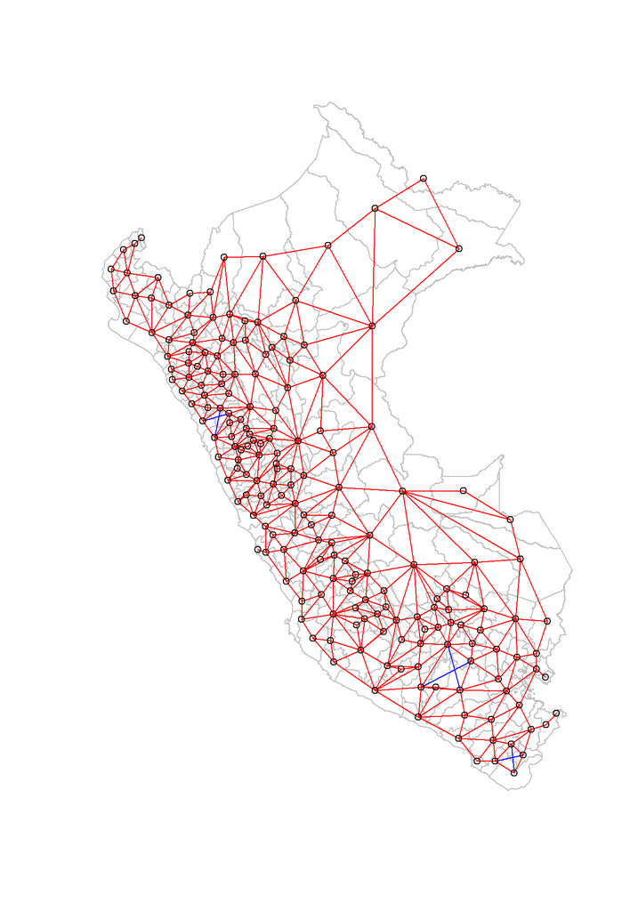

```r
# We can plot the links between neighbors to compare FOQ and FOR approach of neighbors
plot(provincias, border = 'grey')
plot(provincias_foq, coordinates(provincias), add=TRUE, col='blue')
plot(provincias_for, coordinates(provincias), add=TRUE, col='red')
```

**In conclusion, an adjacency matrix under FOQ approach considers as neighbors provinces those sharing edges and vertices as well, whereas, an adjacency matrix under FOR or “rook’s” approach considers as neighbors provinces those sharing only edges. Accordingly, FOR approach has identified fewer links between neighbors than FOQ approach.**